# Lab 11 Sarah

Sarah Liddle

April 4, 2018

## First Three Letters of Names

The ratio of times a name begins with “Sar” in the whole dataset over the times a name contains “sar” is 0.9366. A plot below is shown of that same ratio for each given year.

```r
sarah1<-babynames %>% filter(str_detect(name, "^Sar"))
sarah2<-babynames %>% filter(str_detect(name, "[Ss]ar"))
sum(sarah1$n)/sum(sarah2$n)
```

```
## [1] 0.9366379
```

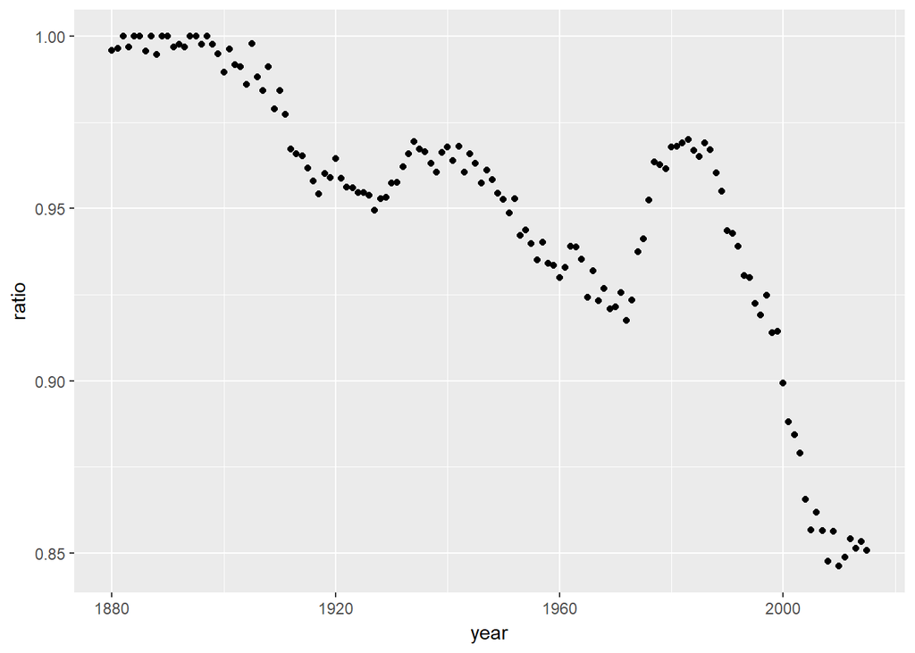

```r
sarahratio1<-sarah1 %>% group_by(year) %>% summarize(startot=sum(n))
sarahratio2<-sarah2 %>% group_by(year) %>% summarize(intot=sum(n))
ratios<-inner_join(sarahratio1,sarahratio2)
ratios<-ratios %>% mutate(ratio=startot/intot)
ggplot(data=ratios)+geom_point(aes(x=year,y=ratio))
```

## Ariel and Rachel regexs

There were one version of the name Ariel in 1973, five versions of the name in 1988, and five versions of the name in 1990. There were 15 versions of the name Rachel for girls born in 1973, 24 versions of the name in 1988, and 21 versios of the name in 1990.

```r
## Dataset for each year
names1973<-filter(babynames, year==1973,sex=="F")
names1988<-filter(babynames, year==1988,sex=="F")
names1990<-filter(babynames, year==1990,sex=="F")

##Rachel
length(str_subset(names1973$name, "^R[aey]*ch[:lower:]*[ale]*$"))
```

```
## [1] 15
```

```r
length(str_subset(names1988$name, "^R[aey]*ch[:lower:]*[ale]*$"))
```

```
## [1] 24
```

```r
length(str_subset(names1990$name, "^R[aey]*ch[:lower:]*[ale]*$"))
```

```
## [1] 21
```

```r
##Ariel
length(str_subset(names1973$name, "Ar[iy]+.le*[^a]?$"))
```

```
## [1] 1
```

```r
length(str_subset(names1988$name, "Ar[iy]+.le*[^a]?$"))
```

```
## [1] 5
```

```r
length(str_subset(names1990$name, "Ar[iy]+.le*[^a]?$"))
```

```
## [1] 5
```

There was about a 0.00295% chance of being names Ariel in 1973, a 0.05% chance in 1988, and a 0.20% chance in 1990. There was about a 0.575% chance of being named Rachel in 1973, a 1.12% chance in 1988, and a 1.08% chance in 1990.

```r
## Ariel
arielnames1973<-names1973 %>% filter(str_detect(name, "Ar[iy]+.le*[^a]?$"))
sum(arielnames1973$n)/sum(names1973$n)
```

```
## [1] 2.948932e-05
```

```r
arielnames1988<-names1988 %>% filter(str_detect(name, "Ar[iy]+.le*[^a]?$"))
sum(arielnames1988$n)/sum(names1988$n)
```

```
## [1] 0.000537648
```

```r
arielnames1990<-names1990 %>% filter(str_detect(name, "Ar[iy]+.le*[^a]?$"))
sum(arielnames1990$n)/sum(names1990$n)
```

```
## [1] 0.001993353
```

```r
## Rachel
rachelnames1973 <-names1973 %>% filter(str_detect(name, "^R[aey]*ch[:lower:]*[ale]*$"))
sum(rachelnames1973$n)/sum(names1973$n)
```

```
## [1] 0.005746303
```

```r
rachelnames1988<-names1988 %>% filter(str_detect(name, "^R[aey]*ch[:lower:]*[ale]*$"))
sum(rachelnames1988$n)/sum(names1988$n)
```

```
## [1] 0.01123106
```

```r
rachelnames1990 <-names1990 %>% filter(str_detect(name, "^R[aey]*ch[:lower:]*[ale]*$"))
sum(rachelnames1990$n)/sum(names1990$n)
```

```
## [1] 0.01075241
```

## The Little Mermaid Effect

In this problem, we aim to find out if the movie, The Little Mermaid, preimiring in 1989 had an affect on little girls being names Ariel in the United States. In order to do this, we compared the change in proportion of girls names Ariel with the change in proportion of all girl names beginning with a vowel.

The plot below is a histogram of the changei n proportion of all girls names starting with a vowel from 1988 to 1990. The vertical line represents the change in proportion of the name Ariel specifically given the time period.

```r
(sum(arielnames1990$n)/sum(names1990$n))-(sum(arielnames1988$n)/sum(names1988$n))
```

```
## [1] 0.001455705
```

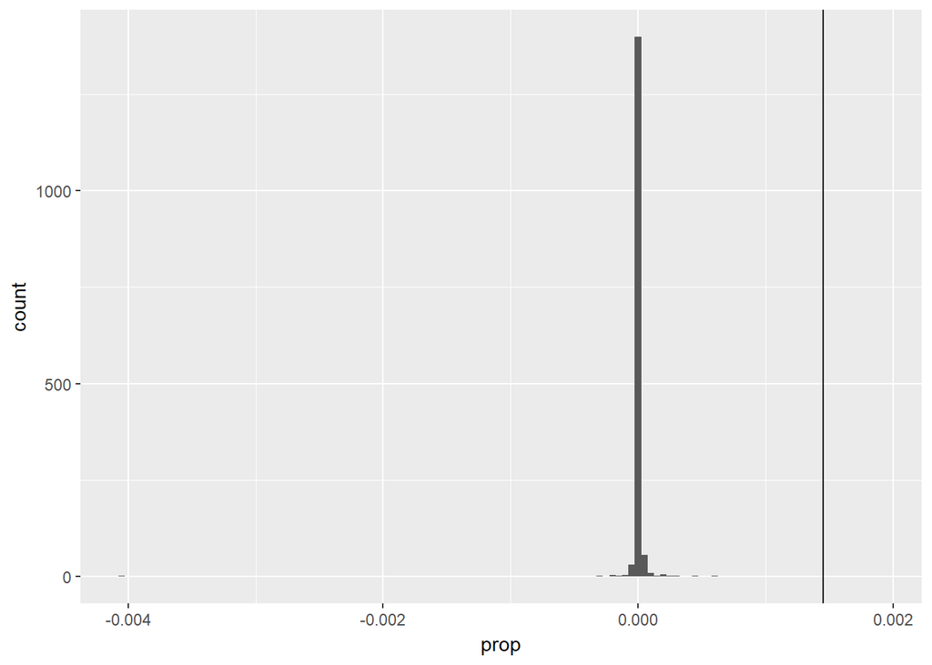

```r
vowelnames1988<-names1988 %>% filter(str_detect(name, "^[AEIOU]"))
#sum(vowelnames1988$n)/sum(names1988$n)
vowelnames1990<-names1990 %>% filter(str_detect(name, "^[AEIOU]"))
#sum(vowelnames1990$n)/sum(names1990$n)

countvowelnames1988<-vowelnames1988 %>% group_by(year,name) %>% summarize(ntot=sum(n))
countvowelnames1990<-vowelnames1990 %>% group_by(year,name) %>% summarize(ntot2=sum(n))


bothnames<-inner_join(countvowelnames1988,countvowelnames1990, by="name")
bothnames<-mutate(bothnames, prop=(ntot2/sum(names1990$n))-(ntot/sum(names1988$n)))
ggplot(data=bothnames)+geom_histogram(aes(x=prop),binwidth=.00005)+geom_vline(xintercept=0.001455705)
```

The change in proportion of Ariel names was about 0.145%. As one cane see, the change in the proportion of the name Ariel between these two years is significantly higher than the majority of girl names that start with a vowel; it is definitely an outlier in all the data. This would suggest that there was something causing this significant increase in baby’s being named Ariel. Since The Little Mermaid was propbably the biggest influence in pop culture of the name Ariel, it is likely that this is the cause of it. From the data, it is fair to suggest that The Little Mermaid did indeed cause an increase in babies names Ariel.

## Our Names

The popularity of the name Sarah decreased by about 0.55% between the years 1997 and 2015 and decreased by about 0.14% between the years 1979 and 1997.

```r
names2015<-babynames %>% filter(year==2015)
names1997<-babynames %>% filter(year==1997)
names1979<-babynames %>% filter(year==1979)
sarah2015<-names2015 %>% filter(str_detect(name, "^Sarah?"))
sarah1997<-names1997 %>% filter(str_detect(name, "^Sarah?"))
sarah1979<-names1979 %>% filter(str_detect(name, "^Sarah?"))
(sum(sarah2015$n)/sum(names2015$n))-(sum(sarah1997$n)/sum(names1997$n))
```

```
## [1] -0.005493895
```

```r
(sum(sarah1997$n)/sum(names1997$n))-(sum(sarah1979$n)/sum(names1979$n))
```

```
## [1] -0.001366348
```

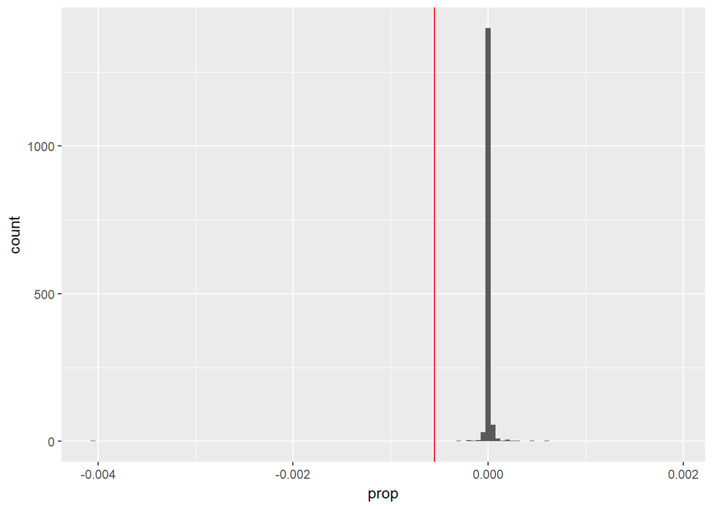

```r
countnames2015<-names2015 %>% group_by(year,name) %>% summarize(ntot2=sum(n))
countnames1997<-names1997 %>% group_by(year,name) %>% summarize(ntot=sum(n))


bothnames2<-inner_join(countnames2015,countnames1997, by="name")
bothnames2<-mutate(bothnames2, prop=(ntot2/sum(names2015$n))-(ntot/sum(names1997$n)))
ggplot(data=bothnames)+geom_histogram(aes(x=prop),binwidth=0.00005)+geom_vline(xintercept=-0.00055, color="red")
```

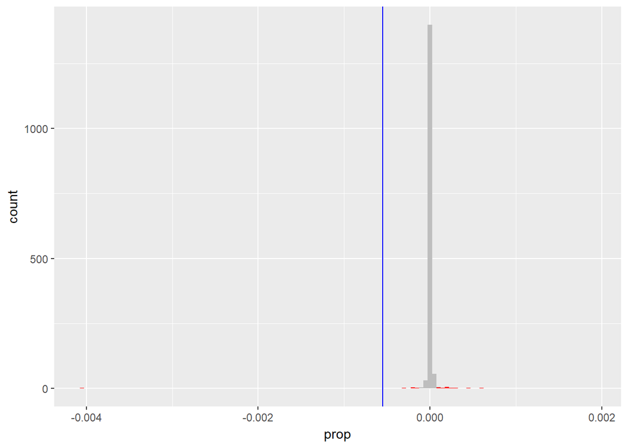

```r
cond<-abs(bothnames$prop)>0.0001
ggplot(bothnames,aes(x=prop))+geom_histogram(data=subset(bothnames,cond==FALSE),fill="grey", binwidth=0.00005)+geom_histogram(data=subset(bothnames,cond==TRUE),fill="red", binwidth=0.00005)+geom_vline(xintercept=-0.00055, color="blue")
```